# NHANES reproduction bioage collaboration

Talia + Calen + Waylon (+ others?)

November 20, 2019

## Load packages

```r
library(RNHANES)
library(haven)
library(psych)
library(dplyr)
library(ggplot2)
library(survey)
library(factoextra)
library(jtools)
library(ggstance)
library(corrplot)
library(GGally)
library(stargazer)
```

## Download data, merge stuff, & do some transformations

```r
demo1 <- nhanes_load_data("DEMO", "1999-2000", demographics = FALSE)
demo2 <- nhanes_load_data("DEMO_B", "2001-2002", demographics = FALSE)

demo1 <- demo1[,c("SEQN", "SDMVPSU", "SDMVSTRA")]
demo2 <- demo2[,c("SEQN", "SDMVPSU", "SDMVSTRA")]
DEMO <- rbind(demo1,demo2)

#### Import smoking aq's

smq1 <- nhanes_load_data("SMQ", "1999-2000", demographics = FALSE)
smq2 <- nhanes_load_data("SMQ_B", "2001-2002", demographics = FALSE)

smq1_short<-smq1[c("SMQ020", "SMQ040", "SEQN")]
smq2_short<-smq2[c("SMQ020", "SMQ040", "SEQN")]
#SMQ020 Smoked 100 cigarettes in life? 1 = yes 2 = no
#SMQ040 DO you now smoke cigarettes? 1 = every day, 2 = some days, 3 = not at all

SMQ<- rbind(smq1_short,smq2_short)

SMQ <- na_if(SMQ, 7)
SMQ <- na_if(SMQ, 9)

SMQ$smoking <- 2 #current smoker
SMQ$smoking[SMQ$SMQ020==2]<-0 #never smoker
SMQ$smoking[SMQ$SMQ040==3]<-1 #past smoker

#remove one person with no SEQN
SMQ <- SMQ[which(SMQ$SEQN>0),]

#### RHQ

rhq1 <- nhanes_load_data("RHQ", "1999-2000", demographics = FALSE)
rhq2 <- nhanes_load_data("RHQ_B", "2001-2002", demographics = FALSE)

rhq1_short<- rhq1[c("SEQN", "RHD130", "RHQ140", "RHQ150", "RHQ160", "RHD170", "RHQ180", "RHQ190", "RHQ200", "RHQ210", "RHD230","RHQ030", "RHQ040", "RHQ060")]
#RHD130 Ever been pregnant? 1 = yes, 2= no
#RHQ140 Think you are pregnant now? 1 = yes, 9 = don't know
#RHQ150 What month of pregnancy are you in? 1-10 = range of values, 99 = don't know
#RHQ160 How many times have you been pregnant? 1-55 = range of values, 77 = refused, 99 = don't know
#RHD170 Number of pregnancies resulting in live births 1-10 = range of values, 11 = 11 or more, 77 = refused
#RHQ180 Age of first live birth 13-41 = range of values, 999= don't know
#RHQ190 Age at last live birth 11-57 = range of values, 999 = don't know
#RHQ200 Now breastfeeding a child? 1 = yes, 2 = no
#RHQ210 breastfed any of your children? 1 = yes, 2 = no
#RHD230 Number of children breastfed at least 1 month 0-13 = range of values
#RHQ030 had regular periods in the last 12 months?
#RHQ040 reason not having regular periods (5= menopause)

rhq2_short<- rhq2[c("SEQN", "RHD130", "RHQ141", "RHQ151", "RHQ160", "RHD170", "RHQ180", "RHQ190", "RHQ200", "RHQ210", "RHD230","RHQ030", "RHQ040", "RHQ060")]
#RHD130 Ever been pregnant? 1 = yes, 2= no, 9 = don't know
#RHQ141 Think you are pregnant now? 1 = yes, 9 = don't know
#RHQ151 What month of pregnancy are you in? 1-9 = range of values, 99 = don't know
#RHQ160 How many times have you been pregnant? 1-18 = range of values, 77 = refused, 99 = don't know
#RHD170 Number of pregnancies resulting in live births 1-10 = range of values, 11 = 11 or more, 77 = refused
#RHQ180 Age of first live birth 12-39 = range of values, 999= don't know
#RHQ190 Age at last live birth 13-57 = range of values, 999 = don't know
#RHQ200 Now breastfeeding a child? 1 = yes, 2 = no
#RHQ210 breastfed any of your children? 1 = yes, 2 = no, don't know = 9
#RHD230 Number of children breastfed at least 1 month 0-13 = range of values, 99 = don't know

#Change column names so can rbind
colnames(rhq2_short)[3:4] <- c("RHQ140","RHQ150")

#Combine cycles
RHQ<- rbind(rhq1_short,rhq2_short)

#Change column names so they don't suck
colnames(RHQ)[2:14] <- c("everpreg", "currentpreg", "currentpregmonth", "timespreg", "livebirths", "firstlivebirth", "lastlivebirth", "currentbreastfeed", "everbreastfed", "numberbreastfed", "mensregularity", "irregreason", "ageLMP")

#Recode the 'refused' and 'don't know's in RHQ data as NA (values differ by variable)
RHQ <- na_if(RHQ, 999)
RHQ <- na_if(RHQ, 77)
RHQ <- na_if(RHQ, 99)
RHQ$everpreg <- na_if(RHQ$everpreg, 9)
RHQ$everbreastfed <- na_if(RHQ$everbreastfed, 9)

RHQSMQ <- merge(RHQ, SMQ, by = "SEQN", all = TRUE)
NHANES <- merge(RHQSMQ, DEMO, by = "SEQN", all = TRUE)

#Create quadratic term for live births
NHANES$livebirths2 <- NHANES$livebirths^2

#Transform the variable indexing whether a woman has ever been pregnant so that 0 = never pregnant, and 1 = ever pregnant
NHANES$everpreg[NHANES$everpreg==2]<-0

#Download biological age file
NHANES_BA_Talia <- read_sav(file.choose())
colnames(NHANES_BA_Talia)[1] <- "SEQN"

#Combine all data
df <- merge(NHANES,NHANES_BA_Talia,by="SEQN")

#Recode race/ethnicity to group all Hispanic-identifying individuals together
df$ridreth1[df$ridreth1==3]<-1

#Create variable for menopause
df$menopause <- NA
df$menopause[df$irregreason==5] <- 1
df$menopause[df$irregreason==1 | df$irregreason==2 | df$irregreason==3 | df$irregreason==4 | df$irregreason==6] <- 0
df$timenoperiod<-df$age-df$ageLMP
df$menopause[df$timenoperiod >1 & (df$irregreason!=1 | df$irregreason!=2 | df$irregreason!=3 | df$irregreason!=4 | df$irregreason!=6 | df$irregreason==5)] <- 1
df$menopause[df$age>61] <- 1
df$menopause[df$age<41] <- 0
df$menopause[df$Gender==2]<-NA
df$menopause[df$mensregularity==1] <- 0
```

## Specify survey designs: # of live births

```r
base <- svydesign(id      = ~SDMVPSU,
                          strata  = ~SDMVSTRA,
                          weights = ~WTMEC4YR,
                          nest    = TRUE,
                          data    = df)

nhanesDesign1<- subset(base, age > 17 & age <=84 & pregnant != 1 & livebirths > -1 & menopause == 0)
nhanesDesign2<- subset(base, age > 17 & age <=84 & pregnant != 1 & livebirths > -1 & menopause == 1)
```

## Most important model (all covariates, no interactions): Premenopausal, # live births

```r
summary(a1 <- svyglm(HD ~ livebirths + livebirths2 + age + bmi + smoking + education + poverty + ridreth1 + food_security, design = nhanesDesign1))
summary(a2 <- svyglm(LM ~ livebirths + livebirths2 + age + bmi + smoking + education + poverty + ridreth1 + food_security, design = nhanesDesign1))
summary(a3 <- svyglm(KDM ~ livebirths + livebirths2 + age + bmi + smoking + education + poverty + ridreth1 + food_security, design = nhanesDesign1))
summary(a4 <- svyglm(log_telo ~ livebirths + livebirths2 + age + bmi + smoking + education + poverty + ridreth1 + food_security, design = nhanesDesign1))
```

## Tables for premenopausal women, # live births

|  | HD | LM | KDM | log_telo |
| --- | --- | --- | --- | --- |
|  | (1) | (2) | (3) | (4) |
| livebirths | -0.065 | -0.968* | -1.106* | 0.006 |
| livebirths2 | 0.013<sup>+</sup> | 0.161* | 0.101 | -0.0005 |
| age | 0.020** | 1.024** | 0.759** | -0.002** |
| bmi | 0.019** | 0.281** | 0.356** | -0.001<sup>+</sup> |
| smoking | 0.045 | 0.798** | 0.246 | -0.001 |
| education | -0.051* | -0.304 | -0.127 | 0.008* |
| poverty | -0.003 | -0.229 | -0.049 | -0.002 |
| ridreth1 | 0.024 | -0.225 | -0.055 | 0.008 |
| food_security | 0.027 | 0.672<sup>+</sup> | 0.219 | -0.001 |
| Constant | 1.826** | -16.375** | -0.153 | 0.125** |
| Observations | 1,099 | 1,128 | 1,138 | 1,020 |
| Log Likelihood | -1,133.008 | -3,618.781 | -3,729.835 | 817.407 |
| Akaike Inf. Crit. | 2,286.015 | 7,257.563 | 7,479.669 | -1,614.814 |
| *Note:* | +p<0.1;*p<0.05;**p<0.01;***p<0.001 |  |  |  |

## Most important model (all covariates, no interactions): Postmenopausal, # live births

```r
summary(b1 <- svyglm(HD ~ livebirths + livebirths2 + age + bmi + smoking + education + poverty + ridreth1 + food_security, design = nhanesDesign2))
summary(b2 <- svyglm(LM ~ livebirths + livebirths2 + age + bmi + smoking + education + poverty + ridreth1 + food_security, design = nhanesDesign2))
summary(b3 <- svyglm(KDM ~ livebirths + livebirths2 + age + bmi + smoking + education + poverty + ridreth1 + food_security, design = nhanesDesign2))
summary(b4 <- svyglm(log_telo ~ livebirths + livebirths2 + age + bmi + smoking + education + poverty + ridreth1 + food_security, design = nhanesDesign2))
```

## Tables for postmenopausal women, # live births

|  | HD | LM | KDM | log_telo |
| --- | --- | --- | --- | --- |
|  | (1) | (2) | (3) | (4) |
| livebirths | -0.033 | 0.197 | -0.702* | 0.003 |
| livebirths2 | 0.003 | -0.003 | 0.063<sup>+</sup> | -0.0003 |
| age | 0.035** | 1.067** | 1.000** | -0.002** |
| bmi | 0.023** | 0.343** | 0.395** | -0.001* |
| smoking | -0.0002 | 0.908** | -0.740<sup>+</sup> | -0.002 |
| education | -0.106** | -0.161 | -0.829** | 0.004 |
| poverty | -0.00004 | -0.397* | -0.065 | 0.001 |
| ridreth1 | 0.105** | 0.673* | 0.872** | 0.001 |
| food_security | 0.102<sup>+</sup> | 0.455 | 0.326 | 0.008<sup>+</sup> |
| Constant | 1.060** | -22.548** | -9.048** | 0.129** |
| Observations | 1,495 | 1,547 | 1,565 | 1,392 |
| Log Likelihood | -1,820.498 | -5,370.011 | -5,708.634 | 940.199 |
| Akaike Inf. Crit. | 3,660.995 | 10,760.020 | 11,437.270 | -1,860.398 |
| *Note:* | +p<0.1;*p<0.05;**p<0.01;***p<0.001 |  |  |  |

## Plots, # live births (model 1 = premenopausal, model 2 = postmenopausal)

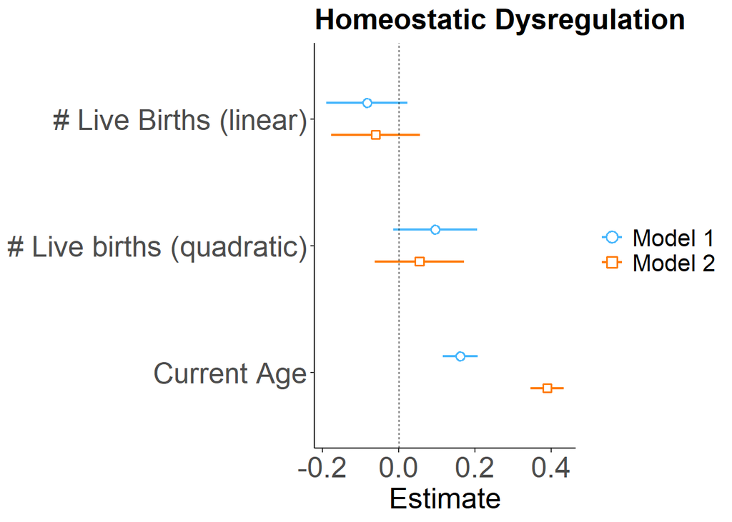

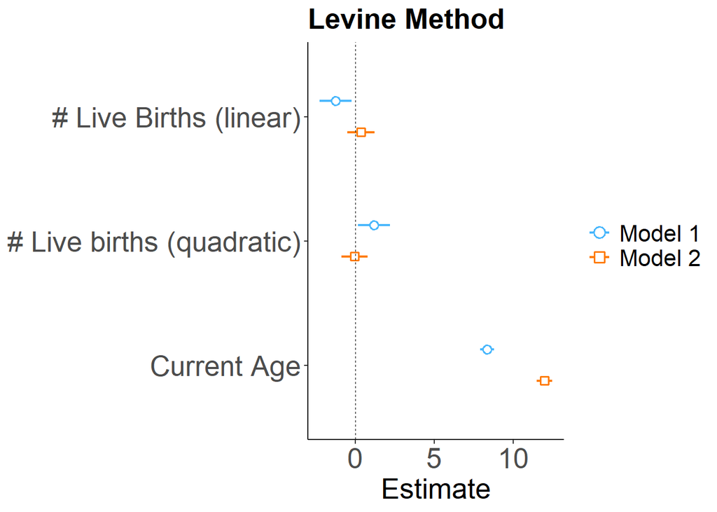

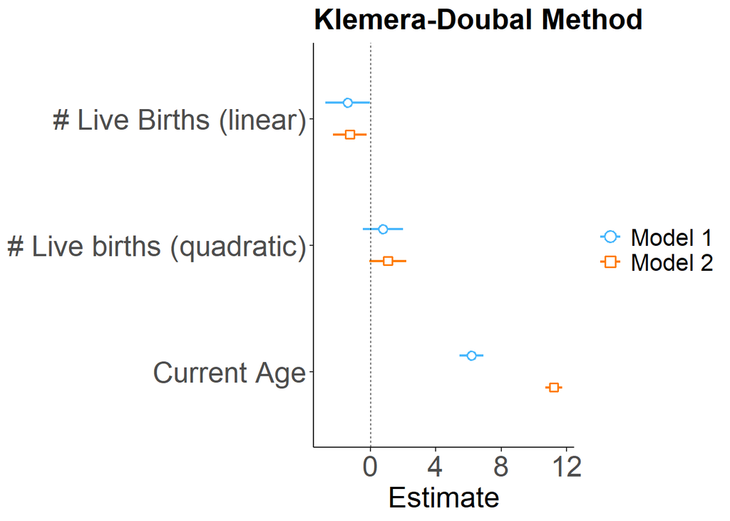

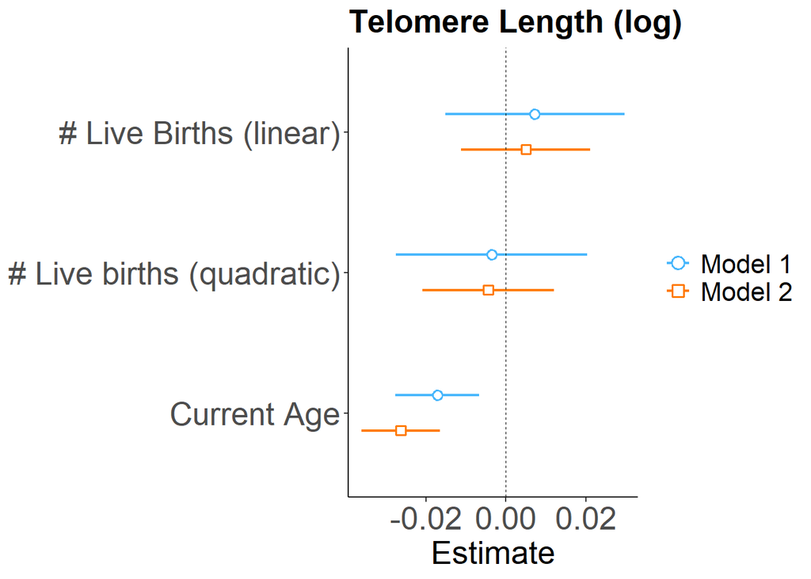

## Specify survey designs: ever pregnant

```r
base <- svydesign(id      = ~SDMVPSU,
                          strata  = ~SDMVSTRA,
                          weights = ~WTMEC4YR,
                          nest    = TRUE,
                          data    = df)

nhanesDesign1<- subset(base, age > 17 & age <=84 & pregnant != 1 & everpreg > -1 & menopause == 0)
nhanesDesign2<- subset(base, age > 17 & age <=84 & pregnant != 1 & everpreg > -1 & menopause == 1)
```

## Most important model (all covariates, no interactions): Premenopausal, ever pregnant

```r
summary(c1 <- svyglm(HD ~ everpreg + age + bmi + smoking + education + poverty + ridreth1 + food_security, design = nhanesDesign1))
summary(c2 <- svyglm(LM ~ everpreg + age + bmi + smoking + education + poverty + ridreth1 + food_security, design = nhanesDesign1))
summary(c3 <- svyglm(KDM ~ everpreg + age + bmi + smoking + education + poverty + ridreth1 + food_security, design = nhanesDesign1))
summary(c4 <- svyglm(log_telo ~ everpreg + age + bmi + smoking + education + poverty + ridreth1 + food_security, design = nhanesDesign1))
```

## Tables for premenopausal women, ever pregnant

|  | HD | LM | KDM | log_telo |
| --- | --- | --- | --- | --- |
|  | (1) | (2) | (3) | (4) |
| everpreg | -0.104* | -0.534 | -1.306<sup>+</sup> | -0.018* |
| age | 0.020** | 1.007** | 0.734** | -0.002** |
| bmi | 0.017** | 0.284** | 0.349** | -0.001* |
| smoking | 0.031 | 0.739** | 0.325<sup>+</sup> | -0.002 |
| education | -0.033<sup>+</sup> | -0.185 | 0.129 | 0.008<sup>+</sup> |
| poverty | -0.003 | -0.201 | -0.012 | -0.006<sup>+</sup> |
| ridreth1 | 0.035* | -0.126 | 0.012 | 0.003 |
| food_security | 0.046 | 0.678<sup>+</sup> | 0.130 | -0.003 |
| Constant | 1.846** | -16.678** | 0.021 | 0.161** |
| Observations | 1,376 | 1,411 | 1,424 | 1,269 |
| Log Likelihood | -1,378.741 | -4,498.852 | -4,638.605 | 1,012.346 |
| Akaike Inf. Crit. | 2,775.482 | 9,015.705 | 9,295.209 | -2,006.692 |
| *Note:* | +p<0.1;*p<0.05;**p<0.01;***p<0.001 |  |  |  |

## Most important model (all covariates, no interactions): Postmenopausal, ever pregnant

```r
summary(d1 <- svyglm(HD ~ everpreg + age + bmi + smoking + education + poverty + ridreth1 + food_security, design = nhanesDesign2))
summary(d2 <- svyglm(LM ~ everpreg + age + bmi + smoking + education + poverty + ridreth1 + food_security, design = nhanesDesign2))
summary(d3 <- svyglm(KDM ~ everpreg + age + bmi + smoking + education + poverty + ridreth1 + food_security, design = nhanesDesign2))
summary(d4 <- svyglm(log_telo ~ everpreg + age + bmi + smoking + education + poverty + ridreth1 + food_security, design = nhanesDesign2))
```

## Tables for postmenopausal women, ever pregnant

|  | HD | LM | KDM | log_telo |
| --- | --- | --- | --- | --- |
|  | (1) | (2) | (3) | (4) |
| everpreg | -0.058 | -0.542 | -1.725 | 0.004 |
| age | 0.034** | 1.068** | 0.994** | -0.002** |
| bmi | 0.023** | 0.351** | 0.396** | -0.001<sup>+</sup> |
| smoking | 0.010 | 0.851** | -0.724* | -0.002 |
| education | -0.093** | -0.180 | -0.608* | 0.004 |
| poverty | 0.001 | -0.389* | -0.014 | 0.0004 |
| ridreth1 | 0.107** | 0.709* | 0.918** | 0.002 |
| food_security | 0.100<sup>+</sup> | 0.514 | 0.454 | 0.008<sup>+</sup> |
| Constant | 1.078** | -21.780** | -8.932** | 0.119* |
| Observations | 1,621 | 1,679 | 1,697 | 1,505 |
| Log Likelihood | -1,974.338 | -5,806.790 | -6,209.590 | 1,030.821 |
| Akaike Inf. Crit. | 3,966.676 | 11,631.580 | 12,437.180 | -2,043.642 |
| *Note:* | +p<0.1;*p<0.05;**p<0.01;***p<0.001 |  |  |  |

## Plots, ever pregnant (model 1 = premenopausal, model 2 = postmenopausal)

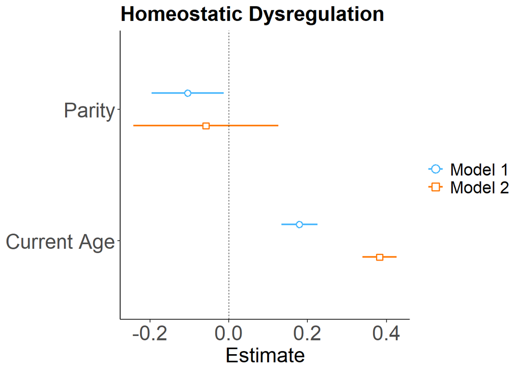

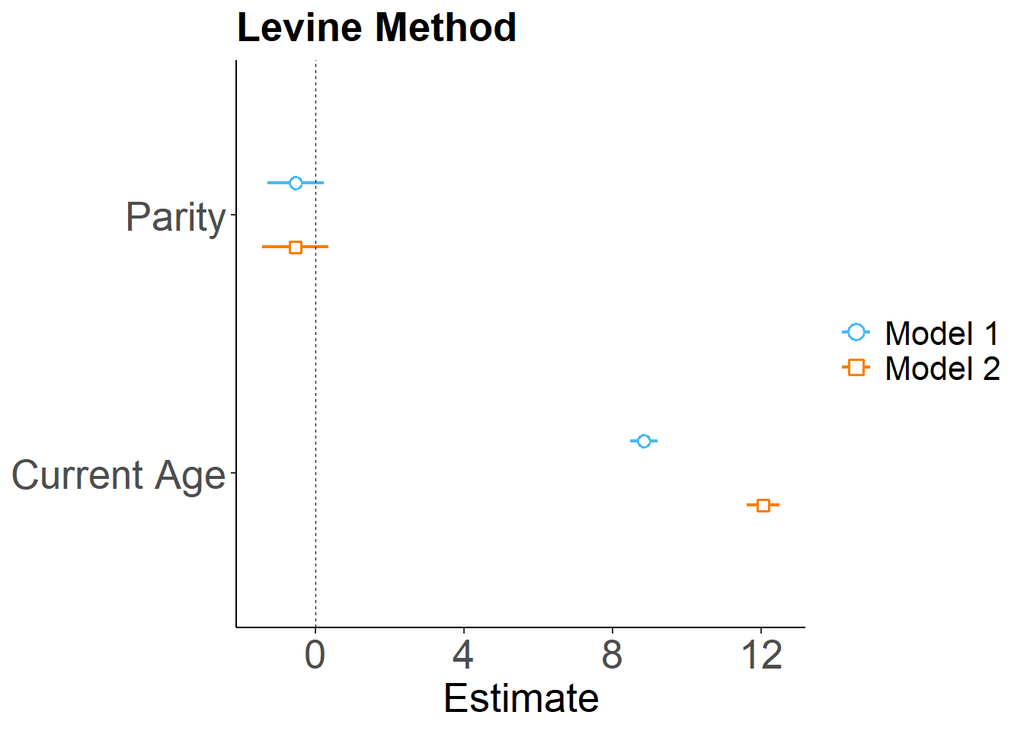

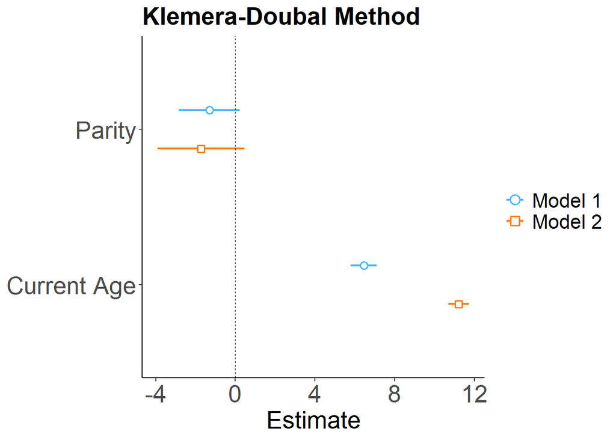

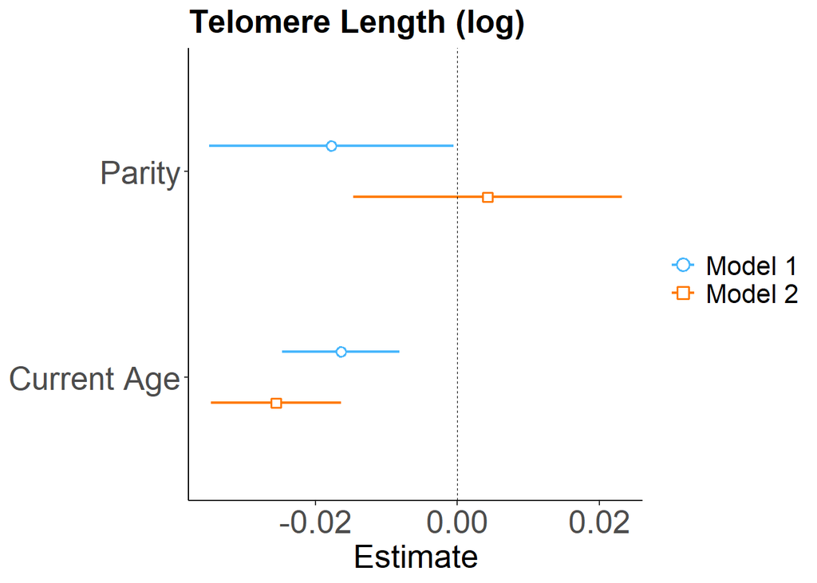

# Base models only adjusted for Chronological Age (stratified by menopausal status)

```r
base <- svydesign(id      = ~SDMVPSU,
                          strata  = ~SDMVSTRA,
                          weights = ~WTMEC4YR,
                          nest    = TRUE,
                          data    = df)

nhanesDesign1<- subset(base, age > 17 & age <=84 & pregnant != 1 & livebirths > -1 & menopause == 0)
nhanesDesign2<- subset(base, age > 17 & age <=84 & pregnant != 1 & livebirths > -1 & menopause == 1)

#Premenopausal
summary(e1 <- svyglm(HD ~ livebirths + livebirths2 + age, design = nhanesDesign1))
```

```
##
## Call:
## svyglm(formula = HD ~ livebirths + livebirths2 + age, design = nhanesDesign1)
##
## Survey design:
## subset(base, age > 17 & age <= 84 & pregnant != 1 & livebirths >
##     -1 & menopause == 0)
##
## Coefficients:
##              Estimate Std. Error t value Pr(>|t|)
## (Intercept)  2.449303   0.092648  26.437  < 2e-16 ***
## livebirths  -0.035203   0.043305  -0.813    0.424
## livebirths2  0.012437   0.008074   1.540    0.136
## age          0.015496   0.002401   6.453 7.74e-07 ***
## ---
## Signif. codes:  0 '***' 0.001 '**' 0.01 '*' 0.05 '.' 0.1 ' ' 1
##
## (Dispersion parameter for gaussian family taken to be 0.3817622)
##
## Number of Fisher Scoring iterations: 2
```

```r
summary(e2 <- svyglm(LM ~ livebirths + livebirths2 + age, design = nhanesDesign1))
```

```
##
## Call:
## svyglm(formula = LM ~ livebirths + livebirths2 + age, design = nhanesDesign1)
##
## Survey design:
## subset(base, age > 17 & age <= 84 & pregnant != 1 & livebirths >
##     -1 & menopause == 0)
##
## Coefficients:
##             Estimate Std. Error t value Pr(>|t|)
## (Intercept) -8.05463    0.78516 -10.259 1.24e-10 ***
## livebirths  -0.41879    0.41610  -1.006   0.3235
## livebirths2  0.12853    0.06755   1.903   0.0682 .
## age          0.98882    0.02111  46.831  < 2e-16 ***
## ---
## Signif. codes:  0 '***' 0.001 '**' 0.01 '*' 0.05 '.' 0.1 ' ' 1
##
## (Dispersion parameter for gaussian family taken to be 32.70601)
##
## Number of Fisher Scoring iterations: 2
```

```r
summary(e3 <- svyglm(KDM ~ livebirths + livebirths2 + age, design = nhanesDesign1))
```

```
##
## Call:
## svyglm(formula = KDM ~ livebirths + livebirths2 + age, design = nhanesDesign1)
##
## Survey design:
## subset(base, age > 17 & age <= 84 & pregnant != 1 & livebirths >
##     -1 & menopause == 0)
##
## Coefficients:
##             Estimate Std. Error t value Pr(>|t|)
## (Intercept)  9.42557    1.10235   8.550 4.97e-09 ***
## livebirths  -0.92268    0.53252  -1.733    0.095 .
## livebirths2  0.10136    0.08599   1.179    0.249
## age          0.76029    0.03539  21.484  < 2e-16 ***
## ---
## Signif. codes:  0 '***' 0.001 '**' 0.01 '*' 0.05 '.' 0.1 ' ' 1
##
## (Dispersion parameter for gaussian family taken to be 37.62327)
##
## Number of Fisher Scoring iterations: 2
```

```r
summary(e4 <- svyglm(log_telo ~ livebirths + livebirths2 + age, design = nhanesDesign1))
```

```
##
## Call:
## svyglm(formula = log_telo ~ livebirths + livebirths2 + age, design = nhanesDesign1)
##
## Survey design:
## subset(base, age > 17 & age <= 84 & pregnant != 1 & livebirths >
##     -1 & menopause == 0)
##
## Coefficients:
##               Estimate Std. Error t value Pr(>|t|)
## (Intercept)  1.056e-01  2.294e-02   4.604 9.56e-05 ***
## livebirths   4.660e-04  9.196e-03   0.051 0.959967
## livebirths2  6.564e-06  1.599e-03   0.004 0.996755
## age         -1.980e-03  5.145e-04  -3.848 0.000694 ***
## ---
## Signif. codes:  0 '***' 0.001 '**' 0.01 '*' 0.05 '.' 0.1 ' ' 1
##
## (Dispersion parameter for gaussian family taken to be 0.009803906)
##
## Number of Fisher Scoring iterations: 2
```

```r
#Postmenopausal
summary(f1 <- svyglm(HD ~ livebirths + livebirths2 + age, design = nhanesDesign2))
```

```
##
## Call:
## svyglm(formula = HD ~ livebirths + livebirths2 + age, design = nhanesDesign2)
##
## Survey design:
## subset(base, age > 17 & age <= 84 & pregnant != 1 & livebirths >
##     -1 & menopause == 1)
##
## Coefficients:
##             Estimate Std. Error t value Pr(>|t|)
## (Intercept) 1.851468   0.128667  14.390 6.79e-14 ***
## livebirths  0.009504   0.027686   0.343    0.734
## livebirths2 0.003042   0.003072   0.990    0.331
## age         0.030789   0.001668  18.456  < 2e-16 ***
## ---
## Signif. codes:  0 '***' 0.001 '**' 0.01 '*' 0.05 '.' 0.1 ' ' 1
##
## (Dispersion parameter for gaussian family taken to be 0.541538)
##
## Number of Fisher Scoring iterations: 2
```

```r
summary(f2 <- svyglm(LM ~ livebirths + livebirths2 + age, design = nhanesDesign2))
```

```
##
## Call:
## svyglm(formula = LM ~ livebirths + livebirths2 + age, design = nhanesDesign2)
##
## Survey design:
## subset(base, age > 17 & age <= 84 & pregnant != 1 & livebirths >
##     -1 & menopause == 1)
##
## Coefficients:
##               Estimate Std. Error t value Pr(>|t|)
## (Intercept) -11.682033   1.015966 -11.498 1.07e-11 ***
## livebirths    0.463050   0.248104   1.866   0.0733 .
## livebirths2  -0.003053   0.026006  -0.117   0.9074
## age           1.040034   0.016994  61.199  < 2e-16 ***
## ---
## Signif. codes:  0 '***' 0.001 '**' 0.01 '*' 0.05 '.' 0.1 ' ' 1
##
## (Dispersion parameter for gaussian family taken to be 50.10732)
##
## Number of Fisher Scoring iterations: 2
```

```r
summary(f3 <- svyglm(KDM ~ livebirths + livebirths2 + age, design = nhanesDesign2))
```

```
##
## Call:
## svyglm(formula = KDM ~ livebirths + livebirths2 + age, design = nhanesDesign2)
##
## Survey design:
## subset(base, age > 17 & age <= 84 & pregnant != 1 & livebirths >
##     -1 & menopause == 1)
##
## Coefficients:
##             Estimate Std. Error t value Pr(>|t|)
## (Intercept)  1.25482    1.36284   0.921    0.366
## livebirths  -0.11408    0.22830  -0.500    0.622
## livebirths2  0.04463    0.02708   1.648    0.111
## age          0.97243    0.01733  56.107   <2e-16 ***
## ---
## Signif. codes:  0 '***' 0.001 '**' 0.01 '*' 0.05 '.' 0.1 ' ' 1
##
## (Dispersion parameter for gaussian family taken to be 69.20541)
##
## Number of Fisher Scoring iterations: 2
```

```r
summary(f4 <- svyglm(log_telo ~ livebirths + livebirths2 + age, design = nhanesDesign2))
```

```
##
## Call:
## svyglm(formula = log_telo ~ livebirths + livebirths2 + age, design = nhanesDesign2)
##
## Survey design:
## subset(base, age > 17 & age <= 84 & pregnant != 1 & livebirths >
##     -1 & menopause == 1)
##
## Coefficients:
##               Estimate Std. Error t value Pr(>|t|)
## (Intercept)  1.193e-01  2.512e-02   4.750 6.50e-05 ***
## livebirths   1.140e-03  4.171e-03   0.273    0.787
## livebirths2 -9.457e-05  4.465e-04  -0.212    0.834
## age         -2.364e-03  3.302e-04  -7.161 1.32e-07 ***
## ---
## Signif. codes:  0 '***' 0.001 '**' 0.01 '*' 0.05 '.' 0.1 ' ' 1
##
## (Dispersion parameter for gaussian family taken to be 0.01061565)
##
## Number of Fisher Scoring iterations: 2
```

# Plots of Biological Age by Chronological Age across different numbers of pregnancies (Premenopausal)

Here are some different plots showing the relationship between chronological age and biological age for various numbers of births. For now we’ll focus on graphs for mdoels only adjusting for chronological age.

Extracting coefficients for each of the models.

```r
coef_HD_pre <- e1$coefficients
coef_LM_pre <- e2$coefficients
coef_KDM_pre <- e3$coefficients
coef_Telo_pre <- e4$coefficients
```

Creating subsets holding individuals that would have all data in model 2 for each aging measure.

```r
df_HD_pre <- subset(df, age>17 & age < 51 & pregnant !=1 & livebirths>-1 & HD >-5 & menopause == 0)
df_LM_pre <- subset(df, age>17 & age < 51 & pregnant !=1 & livebirths>-1 & LM >-11 & menopause == 0)
df_KDM_pre <- subset(df, age>17 & age < 51 & pregnant !=1 & livebirths>-1 & KDM >-5 & menopause == 0)
df_Telo_pre <- subset(df, age>17 & age < 51 & pregnant !=1 & livebirths>-1 & log_telo >-5 & menopause == 0)
```

Homeostatic dysregulation at 0,1,3,5,and 7 births.

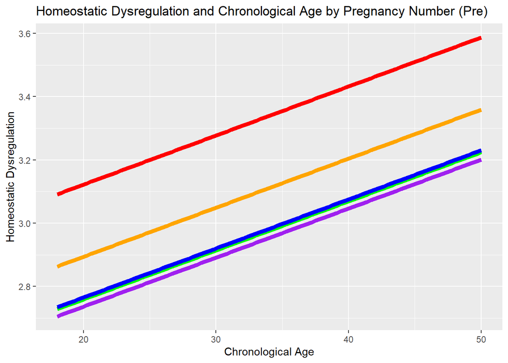

```r
fun_HD_0 <- function(x) {
  livebirths=0
  livebirths2=0
  coef_HD_pre[1] + coef_HD_pre[2]*livebirths + coef_HD_pre[3]*livebirths2 + coef_HD_pre[4]*x
}
fun_HD_1 <- function(x) {
  livebirths=1
  livebirths2=1
   coef_HD_pre[1] + coef_HD_pre[2]*livebirths + coef_HD_pre[3]*livebirths2 + coef_HD_pre[4]*x
}
fun_HD_3 <- function(x) {
  livebirths=3
  livebirths2=9
   coef_HD_pre[1] + coef_HD_pre[2]*livebirths + coef_HD_pre[3]*livebirths2 + coef_HD_pre[4]*x
}
fun_HD_5 <- function(x) {
  livebirths=5
  livebirths2=25
   coef_HD_pre[1] + coef_HD_pre[2]*livebirths + coef_HD_pre[3]*livebirths2 + coef_HD_pre[4]*x
}
fun_HD_7 <- function(x) {
  livebirths=7
  livebirths2=49
   coef_HD_pre[1] + coef_HD_pre[2]*livebirths + coef_HD_pre[3]*livebirths2 + coef_HD_pre[4]*x
}

ggplot(data=df_HD_pre, aes(x = age, y = HD)) +
  ggtitle("Homeostatic Dysregulation and Chronological Age by Pregnancy Number (Pre)") +
  xlab("Chronological Age") +
  ylab("Homeostatic Dysregulation")+
  stat_function(fun=fun_HD_0, color="green", size=2)+
  stat_function(fun=fun_HD_1, color="purple", size=2) +
  stat_function(fun=fun_HD_3, color="blue", size=2) +
  stat_function(fun=fun_HD_5, color="orange", size=2) +
  stat_function(fun=fun_HD_7, color="red", size=2)
```

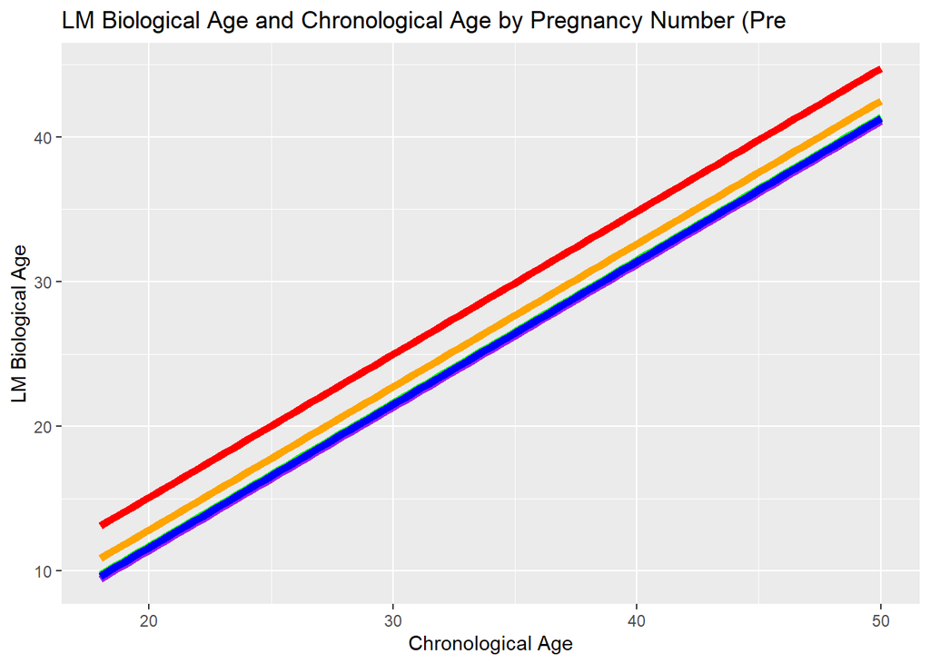

```r
fun_LM_0 <- function(x) {
  livebirths=0
  livebirths2=0
  coef_LM_pre[1] + coef_LM_pre[2]*livebirths + coef_LM_pre[3]*livebirths2 + coef_LM_pre[4]*x
}
fun_LM_1 <- function(x) {
  livebirths=1
  livebirths2=1
   coef_LM_pre[1] + coef_LM_pre[2]*livebirths + coef_LM_pre[3]*livebirths2 + coef_LM_pre[4]*x
}
fun_LM_3 <- function(x) {
  livebirths=3
  livebirths2=9
   coef_LM_pre[1] + coef_LM_pre[2]*livebirths + coef_LM_pre[3]*livebirths2 + coef_LM_pre[4]*x
}
fun_LM_5 <- function(x) {
  livebirths=5
  livebirths2=25
   coef_LM_pre[1] + coef_LM_pre[2]*livebirths + coef_LM_pre[3]*livebirths2 + coef_LM_pre[4]*x
}
fun_LM_7 <- function(x) {
  livebirths=7
  livebirths2=49
   coef_LM_pre[1] + coef_LM_pre[2]*livebirths + coef_LM_pre[3]*livebirths2 + coef_LM_pre[4]*x
}

ggplot(data=df_LM_pre, aes(x = age, y = LM)) +
  ggtitle("LM Biological Age and Chronological Age by Pregnancy Number (Pre") +
  xlab("Chronological Age") +
  ylab("LM Biological Age")+
  stat_function(fun=fun_LM_0, color="green", size=2)+
  stat_function(fun=fun_LM_1, color="purple", size=2) +
  stat_function(fun=fun_LM_3, color="blue", size=2) +
  stat_function(fun=fun_LM_5, color="orange", size=2) +
  stat_function(fun=fun_LM_7, color="red", size=2)
```

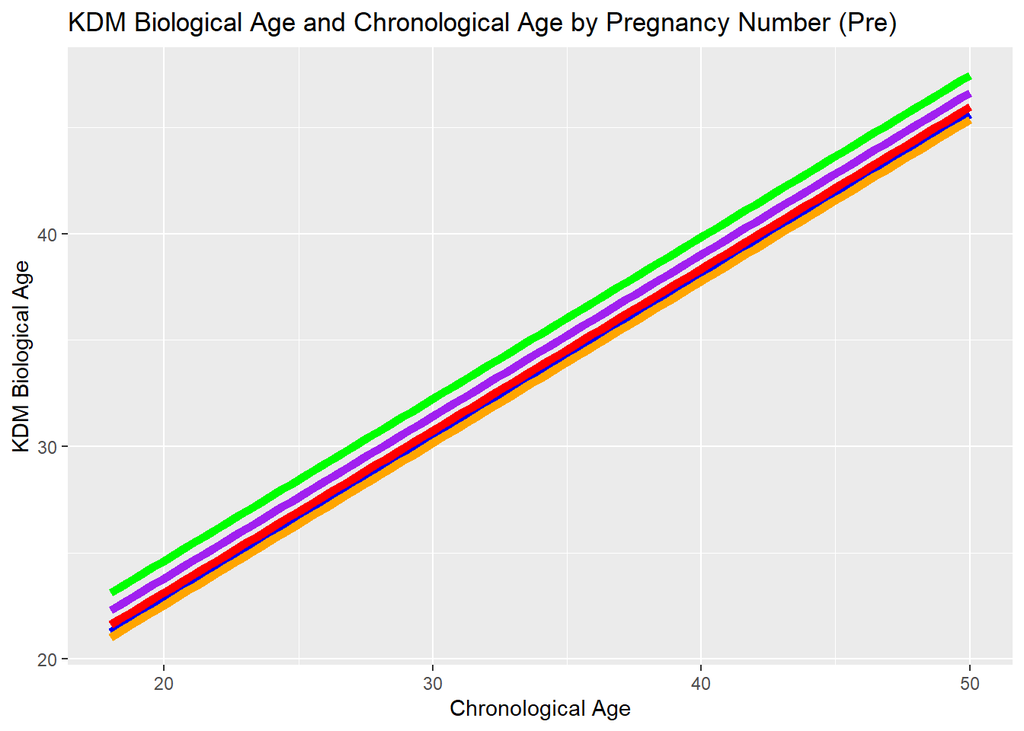

```r
fun_KDM_0 <- function(x) {
  livebirths=0
  livebirths2=0
  coef_KDM_pre[1] + coef_KDM_pre[2]*livebirths + coef_KDM_pre[3]*livebirths2 + coef_KDM_pre[4]*x
}
fun_KDM_1 <- function(x) {
  livebirths=1
  livebirths2=1
   coef_KDM_pre[1] + coef_KDM_pre[2]*livebirths + coef_KDM_pre[3]*livebirths2 + coef_KDM_pre[4]*x
}
fun_KDM_3 <- function(x) {
  livebirths=3
  livebirths2=9
   coef_KDM_pre[1] + coef_KDM_pre[2]*livebirths + coef_KDM_pre[3]*livebirths2 + coef_KDM_pre[4]*x
}
fun_KDM_5 <- function(x) {
  livebirths=5
  livebirths2=25
   coef_KDM_pre[1] + coef_KDM_pre[2]*livebirths + coef_KDM_pre[3]*livebirths2 + coef_KDM_pre[4]*x
}
fun_KDM_7 <- function(x) {
  livebirths=7
  livebirths2=49
   coef_KDM_pre[1] + coef_KDM_pre[2]*livebirths + coef_KDM_pre[3]*livebirths2 + coef_KDM_pre[4]*x
}

ggplot(data=df_KDM_pre, aes(x = age, y = KDM)) +
  ggtitle("KDM Biological Age and Chronological Age by Pregnancy Number (Pre)") +
  xlab("Chronological Age") +
  ylab("KDM Biological Age")+
  stat_function(fun=fun_KDM_0, color="green", size=2)+
  stat_function(fun=fun_KDM_1, color="purple", size=2) +
  stat_function(fun=fun_KDM_3, color="blue", size=2) +
  stat_function(fun=fun_KDM_5, color="orange", size=2) +
  stat_function(fun=fun_KDM_7, color="red", size=2)
```

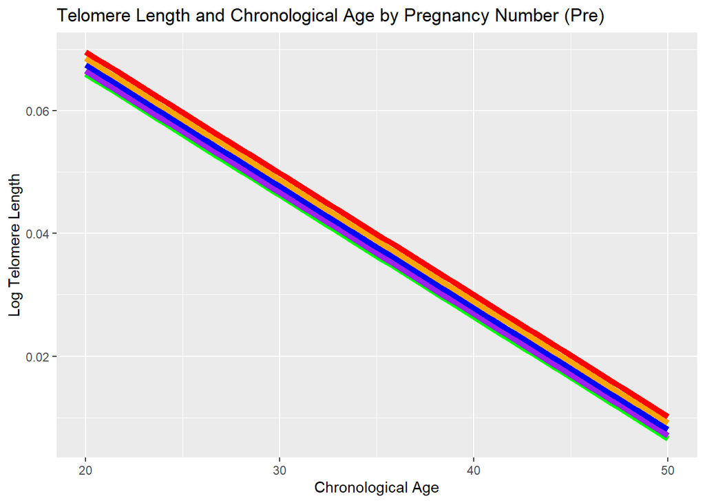

```r
fun_Telo_0 <- function(x) {
  livebirths=0
  livebirths2=0
  coef_Telo_pre[1] + coef_Telo_pre[2]*livebirths + coef_Telo_pre[3]*livebirths2 + coef_Telo_pre[4]*x
}
fun_Telo_1 <- function(x) {
  livebirths=1
  livebirths2=1
   coef_Telo_pre[1] + coef_Telo_pre[2]*livebirths + coef_Telo_pre[3]*livebirths2 + coef_Telo_pre[4]*x
}
fun_Telo_3 <- function(x) {
  livebirths=3
  livebirths2=9
   coef_Telo_pre[1] + coef_Telo_pre[2]*livebirths + coef_Telo_pre[3]*livebirths2 + coef_Telo_pre[4]*x
}
fun_Telo_5 <- function(x) {
  livebirths=5
  livebirths2=25
   coef_Telo_pre[1] + coef_Telo_pre[2]*livebirths + coef_Telo_pre[3]*livebirths2 + coef_Telo_pre[4]*x
}
fun_Telo_7 <- function(x) {
  livebirths=7
  livebirths2=49
   coef_Telo_pre[1] + coef_Telo_pre[2]*livebirths + coef_Telo_pre[3]*livebirths2 + coef_Telo_pre[4]*x
}

ggplot(data=df_Telo_pre, aes(x = age, y = log_telo)) +
  ggtitle("Telomere Length and Chronological Age by Pregnancy Number (Pre)") +
  xlab("Chronological Age") +
  ylab("Log Telomere Length")+
  stat_function(fun=fun_Telo_0, color="green", size=2)+
  stat_function(fun=fun_Telo_1, color="purple", size=2) +
  stat_function(fun=fun_Telo_3, color="blue", size=2) +
  stat_function(fun=fun_Telo_5, color="orange", size=2) +
  stat_function(fun=fun_Telo_7, color="red", size=2)
```

# Plots of Biological Age by Chronological Age across different numbers of pregnancies (Postmenopausal)

Here are some different plots showing the relationship between chronological age and biological age for various numbers of births. For now we’ll focus on graphs for mdoels only adjusting for chronological age.

Extracting coefficients for each of the models.

```r
coef_HD_post <- f1$coefficients
coef_LM_post <- f2$coefficients
coef_KDM_post <- f3$coefficients
coef_Telo_post <- f4$coefficients
```

Creating subsets holding individuals that would have all data in model 2 for each aging measure.

```r
df_HD_post <- subset(df, age>17 & age < 51 & pregnant !=1 & livebirths>-1 & HD >-5 & menopause == 1)
df_LM_post <- subset(df, age>17 & age < 51 & pregnant !=1 & livebirths>-1 & LM >-11 & menopause == 1)
df_KDM_post <- subset(df, age>17 & age < 51 & pregnant !=1 & livebirths>-1 & KDM >-5 & menopause == 1)
df_Telo_post <- subset(df, age>17 & age < 51 & pregnant !=1 & livebirths>-1 & log_telo >-5 & menopause == 1)
```

Homeostatic dysregulation at 0,1,3,5,and 7 births.

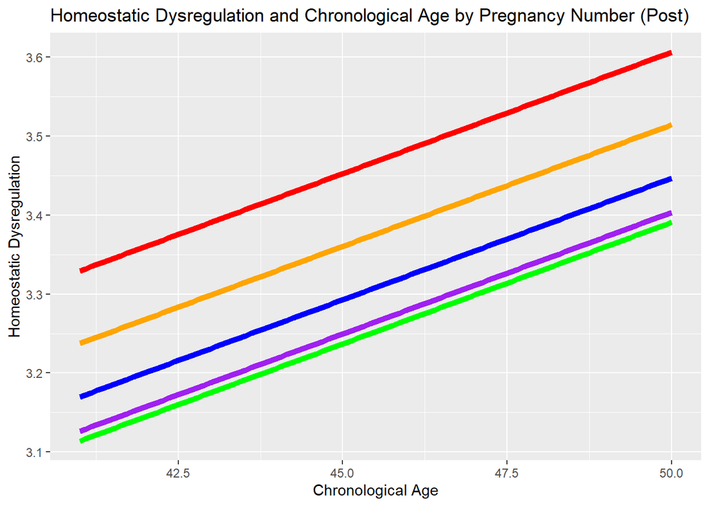

```r
fun_HD_0 <- function(x) {
  livebirths=0
  livebirths2=0
  coef_HD_post[1] + coef_HD_post[2]*livebirths + coef_HD_post[3]*livebirths2 + coef_HD_post[4]*x
}
fun_HD_1 <- function(x) {
  livebirths=1
  livebirths2=1
   coef_HD_post[1] + coef_HD_post[2]*livebirths + coef_HD_post[3]*livebirths2 + coef_HD_post[4]*x
}
fun_HD_3 <- function(x) {
  livebirths=3
  livebirths2=9
   coef_HD_post[1] + coef_HD_post[2]*livebirths + coef_HD_post[3]*livebirths2 + coef_HD_post[4]*x
}
fun_HD_5 <- function(x) {
  livebirths=5
  livebirths2=25
   coef_HD_post[1] + coef_HD_post[2]*livebirths + coef_HD_post[3]*livebirths2 + coef_HD_post[4]*x
}
fun_HD_7 <- function(x) {
  livebirths=7
  livebirths2=49
   coef_HD_post[1] + coef_HD_post[2]*livebirths + coef_HD_post[3]*livebirths2 + coef_HD_post[4]*x
}

ggplot(data=df_HD_post, aes(x = age, y = HD)) +
  ggtitle("Homeostatic Dysregulation and Chronological Age by Pregnancy Number (Post)") +
  xlab("Chronological Age") +
  ylab("Homeostatic Dysregulation")+
  stat_function(fun=fun_HD_0, color="green", size=2)+
  stat_function(fun=fun_HD_1, color="purple", size=2) +
  stat_function(fun=fun_HD_3, color="blue", size=2) +
  stat_function(fun=fun_HD_5, color="orange", size=2) +
  stat_function(fun=fun_HD_7, color="red", size=2)
```

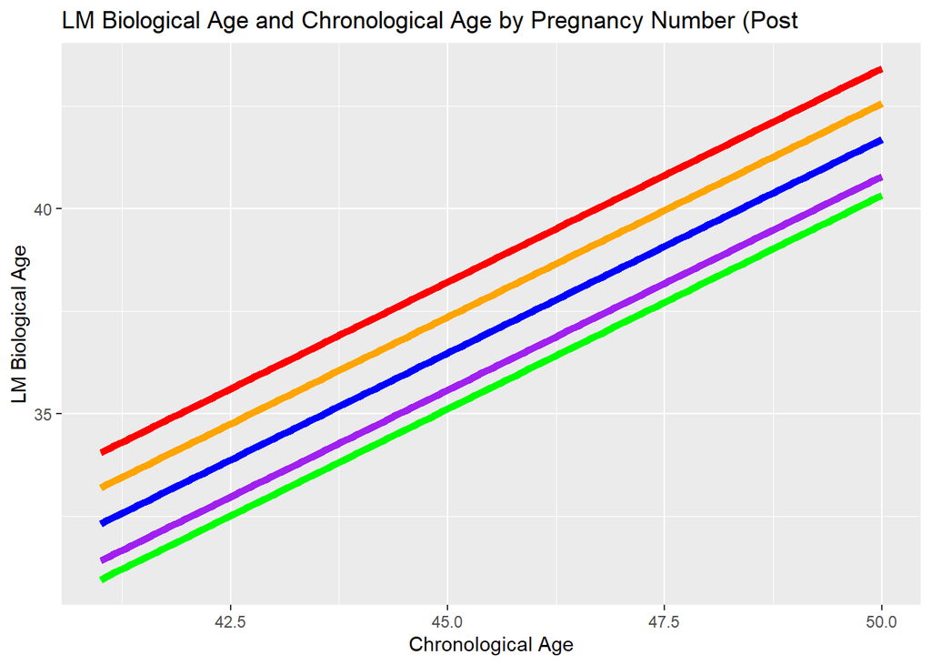

```r
fun_LM_0 <- function(x) {
  livebirths=0
  livebirths2=0
  coef_LM_post[1] + coef_LM_post[2]*livebirths + coef_LM_post[3]*livebirths2 + coef_LM_post[4]*x
}
fun_LM_1 <- function(x) {
  livebirths=1
  livebirths2=1
   coef_LM_post[1] + coef_LM_post[2]*livebirths + coef_LM_post[3]*livebirths2 + coef_LM_post[4]*x
}
fun_LM_3 <- function(x) {
  livebirths=3
  livebirths2=9
   coef_LM_post[1] + coef_LM_post[2]*livebirths + coef_LM_post[3]*livebirths2 + coef_LM_post[4]*x
}
fun_LM_5 <- function(x) {
  livebirths=5
  livebirths2=25
   coef_LM_post[1] + coef_LM_post[2]*livebirths + coef_LM_post[3]*livebirths2 + coef_LM_post[4]*x
}
fun_LM_7 <- function(x) {
  livebirths=7
  livebirths2=49
   coef_LM_post[1] + coef_LM_post[2]*livebirths + coef_LM_post[3]*livebirths2 + coef_LM_post[4]*x
}

ggplot(data=df_LM_post, aes(x = age, y = LM)) +
  ggtitle("LM Biological Age and Chronological Age by Pregnancy Number (Post") +
  xlab("Chronological Age") +
  ylab("LM Biological Age")+
  stat_function(fun=fun_LM_0, color="green", size=2)+
  stat_function(fun=fun_LM_1, color="purple", size=2) +
  stat_function(fun=fun_LM_3, color="blue", size=2) +
  stat_function(fun=fun_LM_5, color="orange", size=2) +
  stat_function(fun=fun_LM_7, color="red", size=2)
```

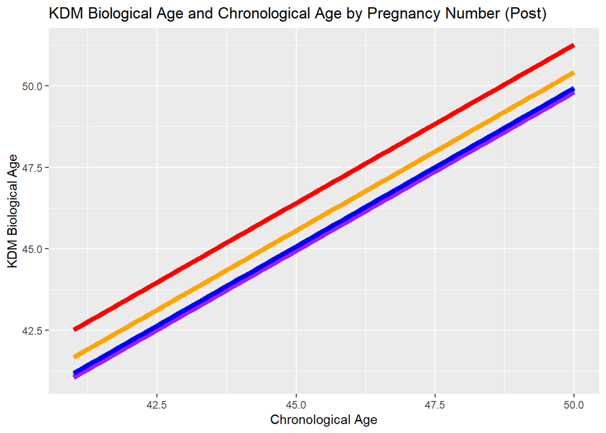

```r
fun_KDM_0 <- function(x) {
  livebirths=0
  livebirths2=0
  coef_KDM_post[1] + coef_KDM_post[2]*livebirths + coef_KDM_post[3]*livebirths2 + coef_KDM_post[4]*x
}
fun_KDM_1 <- function(x) {
  livebirths=1
  livebirths2=1
   coef_KDM_post[1] + coef_KDM_post[2]*livebirths + coef_KDM_post[3]*livebirths2 + coef_KDM_post[4]*x
}
fun_KDM_3 <- function(x) {
  livebirths=3
  livebirths2=9
   coef_KDM_post[1] + coef_KDM_post[2]*livebirths + coef_KDM_post[3]*livebirths2 + coef_KDM_post[4]*x
}
fun_KDM_5 <- function(x) {
  livebirths=5
  livebirths2=25
   coef_KDM_post[1] + coef_KDM_post[2]*livebirths + coef_KDM_post[3]*livebirths2 + coef_KDM_post[4]*x
}
fun_KDM_7 <- function(x) {
  livebirths=7
  livebirths2=49
   coef_KDM_post[1] + coef_KDM_post[2]*livebirths + coef_KDM_post[3]*livebirths2 + coef_KDM_post[4]*x
}

ggplot(data=df_KDM_post, aes(x = age, y = KDM)) +
  ggtitle("KDM Biological Age and Chronological Age by Pregnancy Number (Post)") +
  xlab("Chronological Age") +
  ylab("KDM Biological Age")+
  stat_function(fun=fun_KDM_0, color="green", size=2)+
  stat_function(fun=fun_KDM_1, color="purple", size=2) +
  stat_function(fun=fun_KDM_3, color="blue", size=2) +
  stat_function(fun=fun_KDM_5, color="orange", size=2) +
  stat_function(fun=fun_KDM_7, color="red", size=2)
```

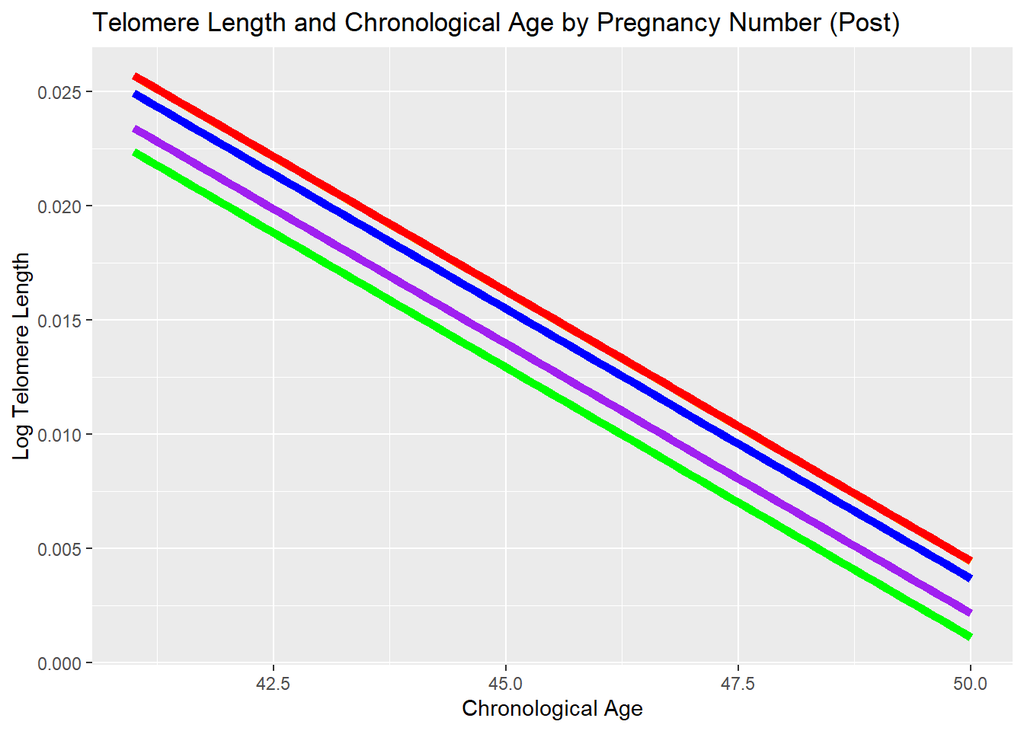

```r
fun_Telo_0 <- function(x) {
  livebirths=0
  livebirths2=0
  coef_Telo_post[1] + coef_Telo_post[2]*livebirths + coef_Telo_post[3]*livebirths2 + coef_Telo_post[4]*x
}
fun_Telo_1 <- function(x) {
  livebirths=1
  livebirths2=1
   coef_Telo_post[1] + coef_Telo_post[2]*livebirths + coef_Telo_post[3]*livebirths2 + coef_Telo_post[4]*x
}
fun_Telo_3 <- function(x) {
  livebirths=3
  livebirths2=9
   coef_Telo_post[1] + coef_Telo_post[2]*livebirths + coef_Telo_post[3]*livebirths2 + coef_Telo_post[4]*x
}
fun_Telo_5 <- function(x) {
  livebirths=5
  livebirths2=25
   coef_Telo_post[1] + coef_Telo_post[2]*livebirths + coef_Telo_post[3]*livebirths2 + coef_Telo_post[4]*x
}
fun_Telo_7 <- function(x) {
  livebirths=7
  livebirths2=49
   coef_Telo_post[1] + coef_Telo_post[2]*livebirths + coef_Telo_post[3]*livebirths2 + coef_Telo_post[4]*x
}

ggplot(data=df_Telo_post, aes(x = age, y = log_telo)) +
  ggtitle("Telomere Length and Chronological Age by Pregnancy Number (Post)") +
  xlab("Chronological Age") +
  ylab("Log Telomere Length")+
  stat_function(fun=fun_Telo_0, color="green", size=2)+
  stat_function(fun=fun_Telo_1, color="purple", size=2) +
  stat_function(fun=fun_Telo_3, color="blue", size=2) +
  stat_function(fun=fun_Telo_5, color="orange", size=2) +
  stat_function(fun=fun_Telo_7, color="red", size=2)
```